# EST077 (2023/1) - Exercicio Computacional I

Gabriela Paschoal 201965038AD

2023-04-22

### Teorema do Limite Central de Forma Empirica

#### O primeiro passo realizado foi a criacao de matrizes para armazenar as 5000 amostras, sendo 1000 amostras para cada matriz. Cada matriz representa um dos tamanhos amostrais n considerados.

```r
# Considere que tem uma população Normal  com média 10 e variância 2, por
# exemplo. Gere 1000 amostras de tamanho n (n=20, 50, 100, 200 e 500)
# provenientes desta população.

amostras20<-matrix(data = NA, nrow = 1000, ncol = 20 )
# cada linha armazena uma amostra de tam 20

i<-1

while (i <= 1000){

      amostras20[i,]<-rnorm(20, mean = 10, sd = sqrt(2))
      i<- i+1

}

any(is.na(amostras20)) # verifica se matriz contem NA's
```

```
## [1] FALSE
```

```r
# ------------------------------------------------------------------------------

amostras50<-matrix(data = NA, nrow = 1000, ncol = 50 )
# cada linha armazena uma amostra de tam 20

i<-1

while (i <= 1000){

      amostras50[i,]<-rnorm(50, mean = 10, sd = sqrt(2))
      i<- i+1

}

any(is.na(amostras50)) # verifica se matriz contem NA's
```

```
## [1] FALSE
```

```r
# ------------------------------------------------------------------------------

amostras100<-matrix(data = NA, nrow = 1000, ncol = 100 )
# cada linha armazena uma amostra de tam 20

i<-1

while (i <= 1000){

      amostras100[i,]<-rnorm(100, mean = 10, sd = sqrt(2))
      i<- i+1

}

any(is.na(amostras100)) # verifica se matriz contem NA's
```

```
## [1] FALSE
```

```r
# ------------------------------------------------------------------------------

amostras200<-matrix(data = NA, nrow = 1000, ncol = 200 )
# cada linha armazena uma amostra de tam 20

i<-1

while (i <= 1000){

      amostras200[i,]<-rnorm(200, mean = 10, sd = sqrt(2))
      i<- i+1

}

any(is.na(amostras200)) # verifica se matriz contem NA's
```

```
## [1] FALSE
```

```r
# ------------------------------------------------------------------------------

amostras500<-matrix(data = NA, nrow = 1000, ncol = 500 )
# cada linha armazena uma amostra de tam 20

i<-1

while (i <= 1000){

      amostras500[i,]<-rnorm(500, mean = 10, sd = sqrt(2))
      i<- i+1

}

any(is.na(amostras500)) # verifica se matriz contem NA's
```

```
## [1] FALSE
```

#### O segundo passo foi a criacao de vetores para armazenar as medias de cada uma das 5000 amostras, sendo um vetor de tamanho 1000 para cada matriz de ordem 1000 x n (ou seja, um vetor para cada 1000 amostras de tamanho n).

```r
#Para cada amostra gerada calcule a média amostral
# e com esses 1000 valores, estude a distribuição da estatística Média Amostral
# (de forma empírica, pois já fizemos isso teoricamente). Faça histograma e descreva
# o que observa. A distribuição da estatística média amostral está
# centrada em qual valor? E sobre a variabilidade, o que pode dizer?
# Lembre-se de repetir este experimento descrito acima para os diversos valores
# de n.

medias20<-numeric(1000)
# vetor para armazenar 1000 medias

i<-1

while (i <= 1000){

      medias20[i]<-mean(amostras20[i,])
      i<-i+1

}

#-------------------------------------------------------------------------------

medias50<-numeric(1000)
i<-1

while (i <= 1000){

      medias50[i]<-mean(amostras50[i,])
      i<-i+1

}

#-------------------------------------------------------------------------------

medias100<-numeric(1000)
i<-1

while (i <= 1000){

      medias100[i]<-mean(amostras100[i,])
      i<-i+1

}

#-------------------------------------------------------------------------------

medias200<-numeric(1000)
i<-1

while (i <= 1000){

      medias200[i]<-mean(amostras200[i,])
      i<-i+1

}

#-------------------------------------------------------------------------------

medias500<-numeric(1000)
i<-1

while (i <= 1000){

      medias500[i]<-mean(amostras500[i,])
      i<-i+1

}
```

#### Por fim, foram plotados histogramas para cada um dos 5 vetores formados.

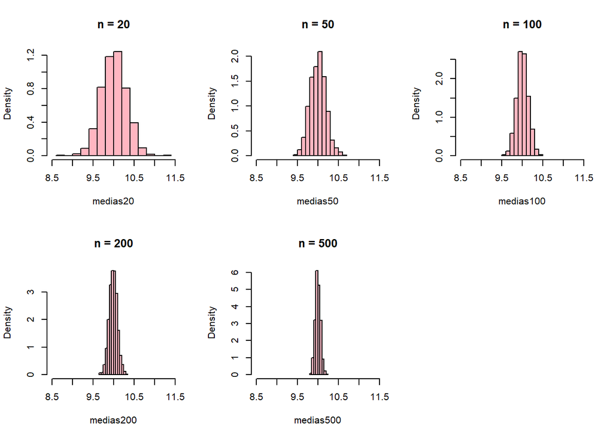

```r
# GRAFICOS ---------------------------------------------------------------------

par(mfrow = c(2,3))

hist(medias20, freq = FALSE, col = 'lightpink', main = 'n = 20', xlim = c(8.5,11.5))
hist(medias50, freq = FALSE, col = 'lightpink', main = 'n = 50', xlim = c(8.5,11.5))
hist(medias100, freq = FALSE, col = 'lightpink', main = 'n = 100', xlim = c(8.5,11.5))
hist(medias200, freq = FALSE, col = 'lightpink', main = 'n = 200', xlim = c(8.5,11.5))
hist(medias500, freq = FALSE, col = 'lightpink', main = 'n = 500', xlim = c(8.5,11.5))
```

### Consideracoes

#### Percebe-se que, conforme o tamanho n da amostra cresce, a media das medias amostrais se concentra cada vez mais proxima da media populacional - ate que, para n suficientemente grande, isso de fato acontece e a media amostral equivale de fato a populacional (conforme esperamos, pois eh o previsto no teorema do limite central).

#### Quanto a variancia, essa decresce conforme n aumenta, evidenciando o aumento da densidade dos dados nos valores mais proximos a media populacional (e conforme tambem ja esperavamos, pois pelo teorema do limite central, o valor esperado da variancia das medias amostrais, para n suficientemente grande, eh a variancia populacional sobre o tamanho n da amostra - ou seja, a variancia eh de fato inversamente proporcional ao tamanho da amostra, por isso a maior concentracao de densidade em torno da media.)